# Simulation experiment (3)

## Design of the experiment

Same as in experiment 1. In this experiment we focus on potential mis-specification of the priors on the intercept and slope. We keep our priors fixed, but we sample now from different values of $\alpha$ and $\beta$. Other parameter values are kept fixed:

Table: Parameter values for the scenario’s of experiment 3.

| Parameter | Values |
| --- | --- |
| $N$ | 200 |
| $\mu_x$ | 0 |
| $\sigma_x$ | 1 |
| $\alpha$ | -0.5, 0, 0.5 |
| $\beta$ | 0.7, 1, 1.3 |
| $\sigma_y$ | 0.1 |
| Tails measurement error | Normal distribution |
| $\tau_x$ | 0.1 |
| $\tau_{xy}$ | 1 |
| $\rho$ | 0 |

## Description of the models

Same as in experiment 1:

- linear regression
- EIV-regression with known SD of measurement error
- EIV-regression with prior on SD of measurement error

## Evaluation of the models

Same as in experiment 1: a validation dataset of $N$ = 1000 observations are sampled from the same data-generating mechanism as the training dataset and the fitted models are used to make predictions. The predictions are compared with the simulated validation data.

## Results

The effect of changing the true $\beta$ is unexpected: I had thought that the predictions would be most accurate when $\beta = 1$ as then the mode of the prior exactly matches the data generating mechanism.

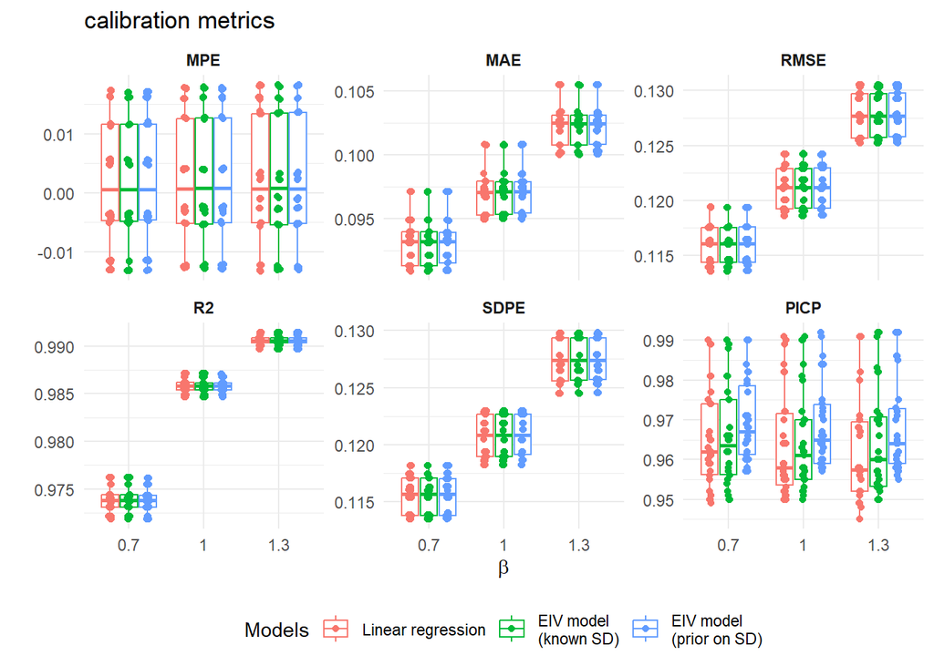

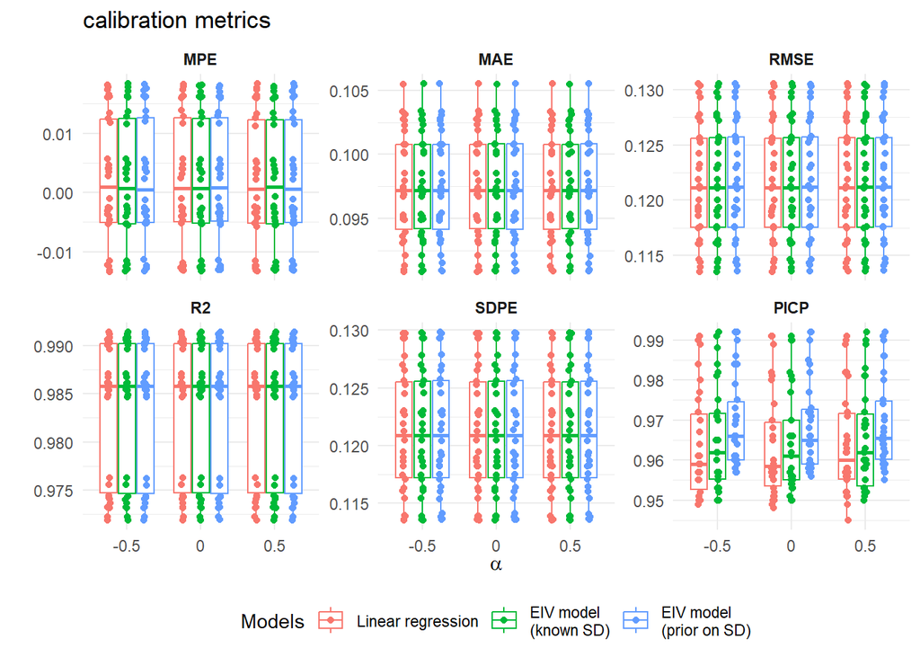

The following figure display the $\hat{R}$ statistic of the MCMC for each of the model parameters. The red dashed lines are at 1.00 and 1.01. The boxplots are aggregated across scenario’s because the values were similar in each of them and all well below 1.01.

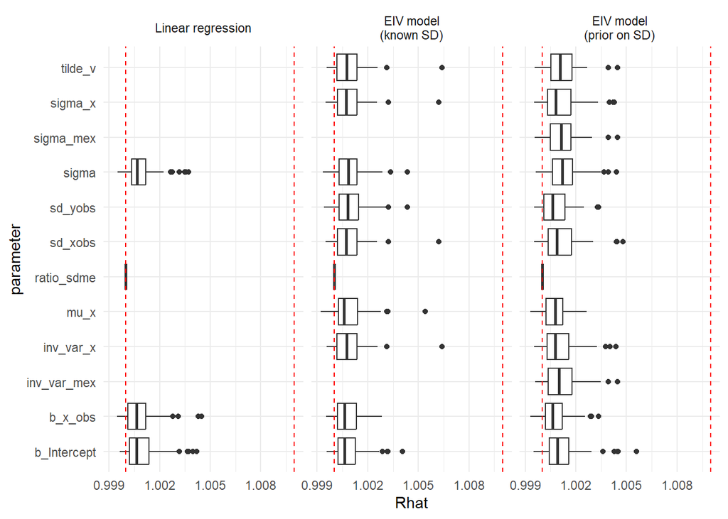